# Day 1

Data de Publicação

29/01/2024

**Código**

```r
## Open packages
pacman::p_load(haven, tidyverse, kableExtra, FactoMineR)

## laod the date

data_ihds <- read_dta("~/IPSA-summer-school-2024/Day 1/1_Assignments/ihds.dta")
```

# 2. What types of variables do you have?

**Código**

```r
glimpse(data_ihds)
```

```
Rows: 39,520
Columns: 18
$ id_religion                  <dbl+lbl> 2, 2, 2, 2, 2, 2, 2, 2, 2, 2, 2, 2, 2…
$ id_caste_category            <dbl+lbl>  3,  3, NA,  3,  2,  2,  2,  3,  3,  …
$ id_income_source             <dbl+lbl> 11, 11,  8,  8,  4,  4,  4,  1,  4,  …
$ id_age                       <dbl> 49, 26, 33, 43, 47, 38, 25, 29, 42, 37, 4…
$ id_marital_status            <dbl+lbl> 1, 1, 1, 1, 1, 1, 1, 1, 1, 1, 3, 1, 3…
$ id_education                 <dbl+lbl>  0,  8, 12,  0,  0,  0,  0,  0,  0,  …
$ decide_cook_respondent       <dbl+lbl> 1, 1, 1, 1, 1, 1, 1, 1, 1, 1, 1, 1, 0…
$ decide_purchase_respondent   <dbl+lbl> 1, 1, 0, 1, 0, 0, 0, 1, 1, 1, 1, 1, 0…
$ decide_children_respondent   <dbl+lbl>  1,  1,  1,  1,  1,  1,  1,  1,  1,  …
$ decide_sick_respondent       <dbl+lbl> 1, 1, 1, 1, 1, 1, 1, 1, 1, 1, 1, 1, 1…
$ decide_land_respondent       <dbl+lbl> 1, 1, 0, 0, 0, 0, 0, 1, 1, 1, 1, 1, 0…
$ decide_wedding_respondent    <dbl+lbl> 1, 1, 1, 1, 1, 0, 1, 1, 1, 1, 1, 1, 0…
$ decide_childsick_respondent  <dbl+lbl>  1,  1,  1,  1,  1,  1,  1,  1,  1,  …
$ decide_childmarry_respondent <dbl+lbl> 1, 1, 1, 1, 1, 1, 1, 1, 1, 1, 1, 1, 1…
$ married_age                  <dbl> 10, 18, 20, 20, 22, 19, 18, 23, 16, 10, 1…
$ married_distance_fam         <dbl+lbl>  1,  3,  3,  2,  2,  1,  1,  2,  5, 6…
$ married_N_marriages          <dbl> NA, NA, NA, NA, NA, NA, NA, NA, NA, NA, N…
$ married_first_age            <dbl> NA, NA, NA, NA, NA, NA, NA, NA, NA, NA, N…
```

**Código**

```r
#unique(data_ihds$id_religion)
```

We have 8 dichotomous, 2 categorical, 3 ordinal, 0 continuous and 5 discretes.

## 3. What is the first age at which each woman in the dataset was married?

**Código**

```r
marriage_age <- data_ihds %>%
  select(married_first_age) %>%
  count(married_first_age)  %>%
  kbl() %>%
  kable_paper(full_width = F)

marriage_age
```

| married_first_age | n |
| --- | --- |
| 0 | 11 |
| 1 | 1 |
| 2 | 1 |
| 3 | 4 |
| 5 | 6 |
| 6 | 5 |
| 7 | 8 |
| 8 | 11 |
| 9 | 3 |
| 10 | 18 |
| 11 | 4 |
| 12 | 43 |
| 13 | 28 |
| 14 | 54 |
| 15 | 76 |
| 16 | 70 |
| 17 | 47 |
| 18 | 71 |
| 19 | 12 |
| 20 | 18 |
| 21 | 5 |
| 22 | 10 |
| 23 | 4 |
| 24 | 5 |
| 25 | 1 |
| 26 | 1 |
| 27 | 1 |
| 31 | 1 |
| 32 | 1 |
| 37 | 1 |
| NA | 38999 |

The reason for the discrepancy between married people (34671) and married_fisrt_agr respondents (521) may be due to social constraint to give the real answer, or they may not be sure about/remember the answer.

**Código**

```r
table(data_ihds$id_marital_status)
```

```
    0     1     3     4
 2252 34671  2207   390
```

# 3.1 Correcting missing problems

Creating a new variable:

**Código**

```r
married_first_age_complete_d <- data_ihds %>%
  mutate(married_first_age_complete = id_age - married_age)

marriage_age <- data_ihds %>%
  select(married_first_age) %>%
  count(married_first_age)  %>%
  kbl() %>%
  kable_paper(full_width = F)
```

# 4. Plot a density plot of your variable for age of first marriage

**Código**

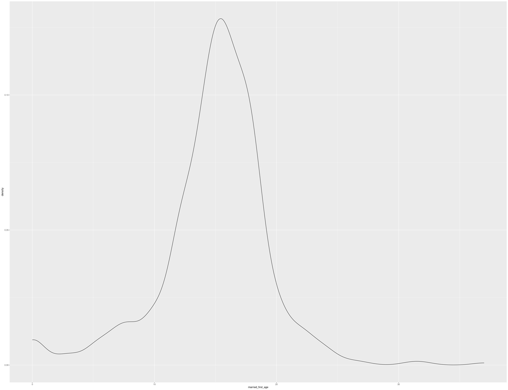

```r
data_ihds %>%
  ggplot(aes(x= married_first_age)) +
  geom_density()
```

# 5. Plot a histogram of the variable for caste (id_caste_category)

**Código**

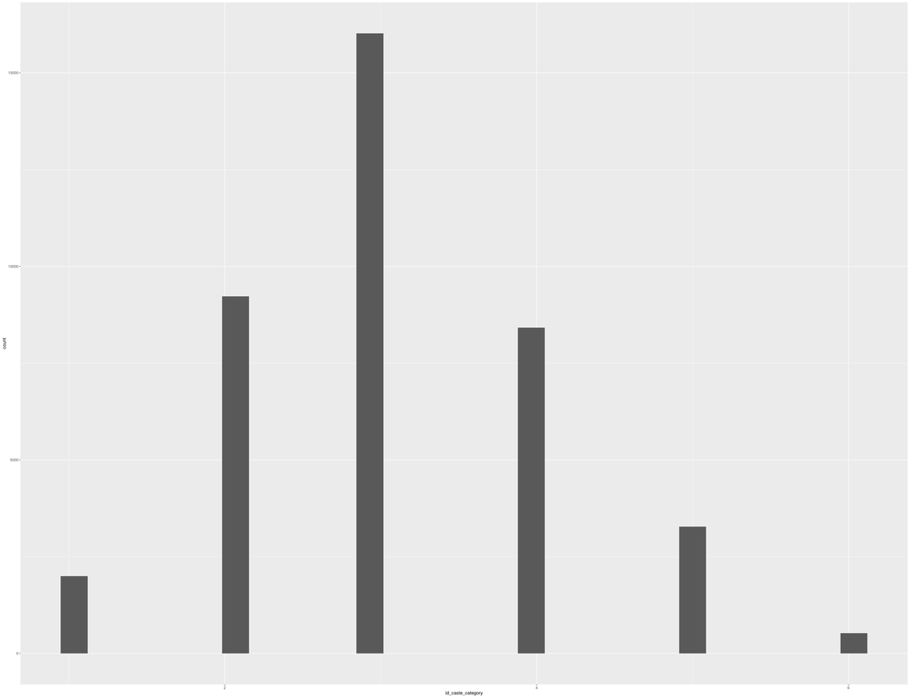

```r
data_ihds %>%
  ggplot(aes(x= id_caste_category)) +
  geom_histogram()
```

# 6. Recode the education variable so that it is a categorical variable with five categories: No Education, 1st-5thClass, 6th-9thClass, Secondary –High Secondary, and More than High Secondary.

**Código**

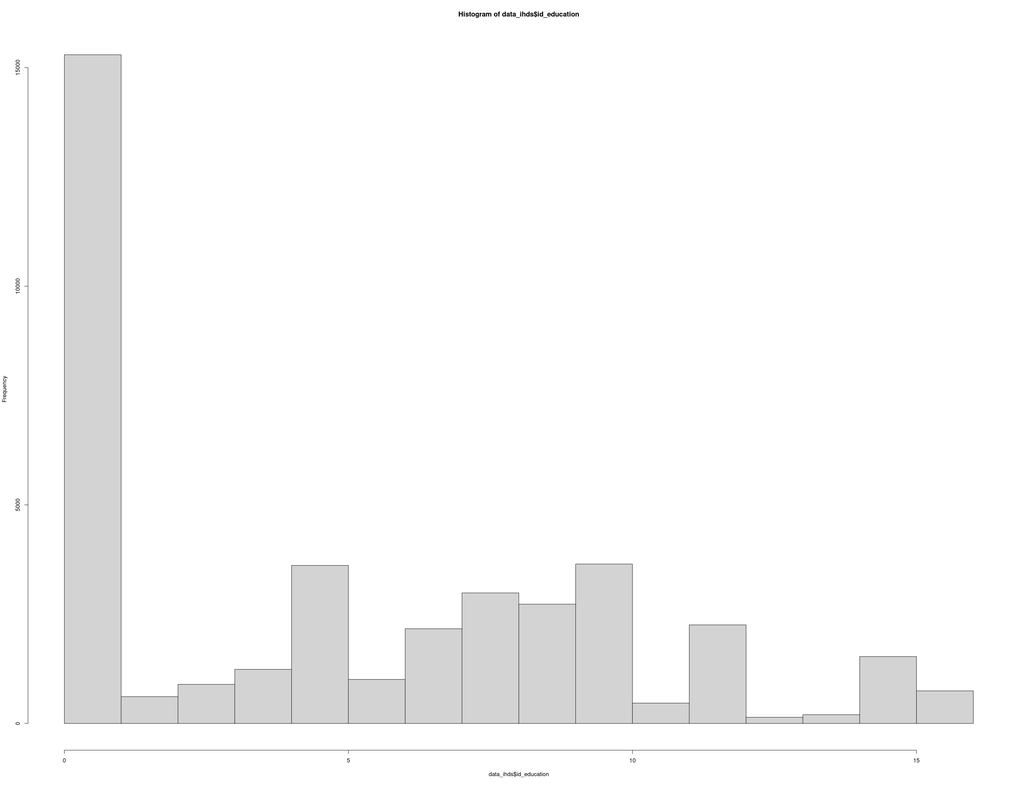

```r
hist(data_ihds$id_education)
```

The age range in data is from 0 to 16 years of education.

**Código**

```r
data_ihds <- data_ihds %>%
  #select(id_education) %>%
  mutate(id_education_recoded = case_when(id_education == 0 ~ "No Education",
                                          id_education <= 1 & id_education <= 5 ~ "1st-5thClass",
                                          id_education <= 6 & id_education <= 9 ~ "6th-9thClass",
                                          id_education <= 10 & id_education <= 12 ~ "Secondary –High Secondary",
                                          id_education <= 13 & id_education <= 16 ~ "More than High Secondary"))
```

# 7. Run a cross-tabulation using your new education variable and id_caste_category

**Código**

```r
table(data_ihds$id_education_recoded, data_ihds$id_caste_category)
```

```
                               1    2    3    4    5    6
  1st-5thClass                 2   26   58   26   18    1
  6th-9thClass               339 1592 3101 1644  572  109
  More than High Secondary   253  984 1055  381  138   44
  No Education               296 2319 6397 4113 1869  147
  Secondary –High Secondary  726 3314 4634 2037  604  189
```

# 8. Using all of the variables on decision-making (beginning with decide_) construct an index as the arithmetic sum of all measures.

**Código**

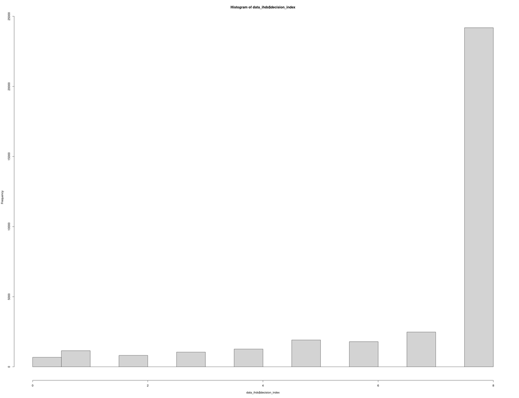

```r
data_ihds <- data_ihds %>%
  mutate(decision_index = decide_cook_respondent + decide_purchase_respondent+ decide_children_respondent + decide_sick_respondent +
           decide_land_respondent + decide_wedding_respondent + decide_childsick_respondent + decide_childmarry_respondent)


hist(data_ihds$decision_index)
```

# 9. Construct another index using the same variables by taking the mean (in this case proportion of 1’s) across all of the variables.

**Código**

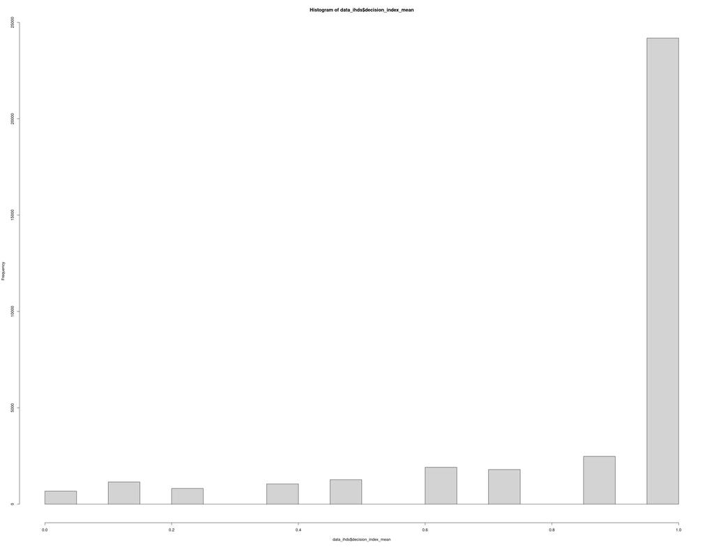

```r
data_ihds <- data_ihds %>%
  mutate(decision_index_mean = c(decide_cook_respondent + decide_purchase_respondent+ decide_children_respondent + decide_sick_respondent + decide_land_respondent + decide_wedding_respondent + decide_childsick_respondent + decide_childmarry_respondent) /8)

hist(data_ihds$decision_index_mean)
```